# Risk Factor Analysis

## Outcome Variable

**Outcome Variable:** haz

## Predictor Variables

**Intervention Variable:** studyid

**Adjustment Set:**

unadjusted

## Stratifying Variables

The analysis was stratified on these variable(s):

- agecat

## Data Summary

| agecat | studyid | n_cell | n |
| --- | --- | --- | --- |
| Birth | ki0047075b-MAL-ED | 1499 | 62600 |
| Birth | ki1000108-CMC-V-BCS-2002 | 90 | 62600 |
| Birth | ki1000108-IRC | 388 | 62600 |
| Birth | ki1000109-EE | 2 | 62600 |
| Birth | ki1000109-ResPak | 7 | 62600 |
| Birth | ki1000304b-SAS-CompFeed | 187 | 62600 |
| Birth | ki1000304b-SAS-FoodSuppl | 0 | 62600 |
| Birth | ki1017093-NIH-Birth | 28 | 62600 |
| Birth | ki1017093b-PROVIDE | 0 | 62600 |
| Birth | ki1017093c-NIH-Crypto | 27 | 62600 |
| Birth | ki1066203-TanzaniaChild2 | 0 | 62600 |
| Birth | ki1101329-Keneba | 1541 | 62600 |
| Birth | ki1112895-Guatemala BSC | 0 | 62600 |
| Birth | ki1113344-GMS-Nepal | 0 | 62600 |
| Birth | ki1114097-CMIN | 138 | 62600 |
| Birth | ki1114097-CONTENT | 2 | 62600 |
| Birth | ki1119695-PROBIT | 13884 | 62600 |
| Birth | ki1126311-ZVITAMBO | 13830 | 62600 |
| Birth | ki1135781-COHORTS | 10542 | 62600 |
| Birth | ki1148112-LCNI-5 | 0 | 62600 |
| Birth | kiGH5241-JiVitA-3 | 19613 | 62600 |
| Birth | kiGH5241-JiVitA-4 | 822 | 62600 |
| 6 months | ki0047075b-MAL-ED | 1696 | 70727 |
| 6 months | ki1000108-CMC-V-BCS-2002 | 369 | 70727 |
| 6 months | ki1000108-IRC | 407 | 70727 |
| 6 months | ki1000109-EE | 372 | 70727 |
| 6 months | ki1000109-ResPak | 235 | 70727 |
| 6 months | ki1000304b-SAS-CompFeed | 1336 | 70727 |
| 6 months | ki1000304b-SAS-FoodSuppl | 380 | 70727 |
| 6 months | ki1017093-NIH-Birth | 537 | 70727 |
| 6 months | ki1017093b-PROVIDE | 583 | 70727 |
| 6 months | ki1017093c-NIH-Crypto | 715 | 70727 |
| 6 months | ki1066203-TanzaniaChild2 | 2029 | 70727 |
| 6 months | ki1101329-Keneba | 2089 | 70727 |
| 6 months | ki1112895-Guatemala BSC | 299 | 70727 |
| 6 months | ki1113344-GMS-Nepal | 563 | 70727 |
| 6 months | ki1114097-CMIN | 1836 | 70727 |
| 6 months | ki1114097-CONTENT | 215 | 70727 |
| 6 months | ki1119695-PROBIT | 15761 | 70727 |
| 6 months | ki1126311-ZVITAMBO | 8295 | 70727 |
| 6 months | ki1135781-COHORTS | 10529 | 70727 |
| 6 months | ki1148112-LCNI-5 | 839 | 70727 |
| 6 months | kiGH5241-JiVitA-3 | 16811 | 70727 |
| 6 months | kiGH5241-JiVitA-4 | 4831 | 70727 |
| 24 months | ki0047075b-MAL-ED | 1489 | 34719 |
| 24 months | ki1000108-CMC-V-BCS-2002 | 372 | 34719 |
| 24 months | ki1000108-IRC | 409 | 34719 |
| 24 months | ki1000109-EE | 0 | 34719 |
| 24 months | ki1000109-ResPak | 0 | 34719 |
| 24 months | ki1000304b-SAS-CompFeed | 0 | 34719 |
| 24 months | ki1000304b-SAS-FoodSuppl | 0 | 34719 |
| 24 months | ki1017093-NIH-Birth | 429 | 34719 |
| 24 months | ki1017093b-PROVIDE | 577 | 34719 |
| 24 months | ki1017093c-NIH-Crypto | 514 | 34719 |
| 24 months | ki1066203-TanzaniaChild2 | 6 | 34719 |
| 24 months | ki1101329-Keneba | 1725 | 34719 |
| 24 months | ki1112895-Guatemala BSC | 0 | 34719 |
| 24 months | ki1113344-GMS-Nepal | 499 | 34719 |
| 24 months | ki1114097-CMIN | 1222 | 34719 |
| 24 months | ki1114097-CONTENT | 164 | 34719 |
| 24 months | ki1119695-PROBIT | 4035 | 34719 |
| 24 months | ki1126311-ZVITAMBO | 457 | 34719 |
| 24 months | ki1135781-COHORTS | 8858 | 34719 |
| 24 months | ki1148112-LCNI-5 | 579 | 34719 |
| 24 months | kiGH5241-JiVitA-3 | 8632 | 34719 |
| 24 months | kiGH5241-JiVitA-4 | 4752 | 34719 |

The following strata were considered:

- agecat: 24 months
- agecat: 6 months
- agecat: Birth

### Dropped Strata

Some strata were dropped due to rare outcomes:

- agecat: Birth
- agecat: 24 months

## Methods Detail

We’re interested in the causal parameters $E[Y_a]$ for all values of $a \in \mathcal{A}$. These parameters represent the mean outcome if, possibly contrary to fact, we intervened to set all units to have $A=a$. Under the randomization and positivity assumptions, these are identified by the statistical parameters $\psi_a=E_W[E_{Y|A,W}(Y|A=a,W)]$. In addition, we’re interested in the mean of $Y$, $E[Y]$ under no intervention (the observed mean). We will estimate these parameters by using SuperLearner to fit the relevant likelihood factors – $E_{Y|A,W}(Y|A=a,W)$ and $p(A=a|W)$, and then updating our likelihood fit using a joint TMLE.

For unadjusted analyses ($W=\{\}$), initial likelihoods were estimated using Lrnr_glm to estimate the simple $E(Y|A)$ and Lrnr_mean to estimate $p(A)$. For adjusted analyses, a small library containing Lrnr_glmnet, Lrnr_xgboost, and Lrnr_mean was used.

Having estimated these parameters, we will then use the delta method to estimate relative risks and attributable risks relative to a prespecified baseline level of $A$.

# Results Detail

## Results Plots

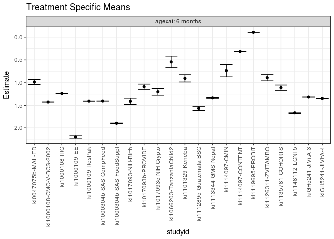

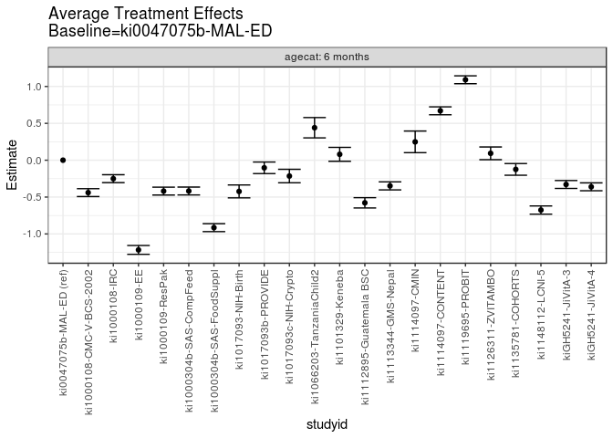

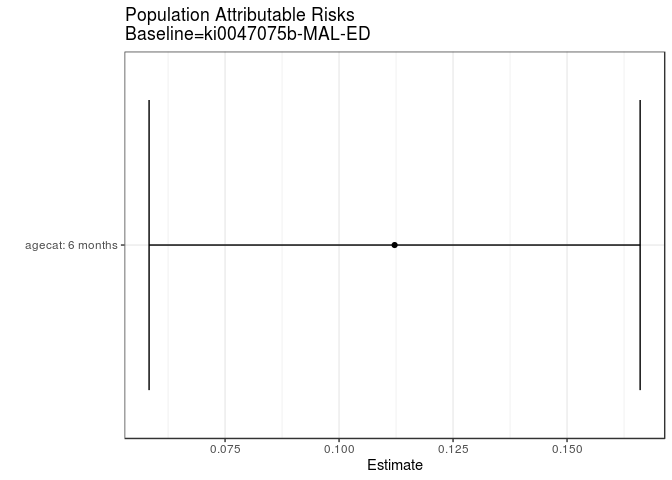

## Results Table

### Parameter: TSM

| agecat | intervention_level | baseline_level | estimate | ci_lower | ci_upper |
| --- | --- | --- | --- | --- | --- |
| 6 months | ki0047075b-MAL-ED | NA | -0.9838360 | -1.0373262 | -0.9303458 |
| 6 months | ki1000108-CMC-V-BCS-2002 | NA | -1.4234508 | -1.4255964 | -1.4213051 |
| 6 months | ki1000108-IRC | NA | -1.2344062 | -1.2365983 | -1.2322142 |
| 6 months | ki1000109-EE | NA | -2.2004704 | -2.2264013 | -2.1745395 |
| 6 months | ki1000109-ResPak | NA | -1.4029220 | -1.4047110 | -1.4011330 |
| 6 months | ki1000304b-SAS-CompFeed | NA | -1.4018563 | -1.4020692 | -1.4016434 |
| 6 months | ki1000304b-SAS-FoodSuppl | NA | -1.8986842 | -1.9035666 | -1.8938018 |
| 6 months | ki1017093-NIH-Birth | NA | -1.4073821 | -1.4767118 | -1.3380523 |
| 6 months | ki1017093b-PROVIDE | NA | -1.0871041 | -1.1444547 | -1.0297534 |
| 6 months | ki1017093c-NIH-Crypto | NA | -1.1986783 | -1.2725922 | -1.1247644 |
| 6 months | ki1066203-TanzaniaChild2 | NA | -0.5434389 | -0.6702135 | -0.4166643 |
| 6 months | ki1101329-Keneba | NA | -0.9041369 | -0.9836906 | -0.8245832 |
| 6 months | ki1112895-Guatemala BSC | NA | -1.5619008 | -1.6066481 | -1.5171534 |
| 6 months | ki1113344-GMS-Nepal | NA | -1.3321522 | -1.3413694 | -1.3229350 |
| 6 months | ki1114097-CMIN | NA | -0.7351262 | -0.8716696 | -0.5985828 |
| 6 months | ki1114097-CONTENT | NA | -0.3139217 | -0.3153283 | -0.3125151 |
| 6 months | ki1119695-PROBIT | NA | 0.1069986 | 0.1065857 | 0.1074115 |
| 6 months | ki1126311-ZVITAMBO | NA | -0.8907480 | -0.9582906 | -0.8232055 |
| 6 months | ki1135781-COHORTS | NA | -1.1085526 | -1.1669104 | -1.0501947 |
| 6 months | ki1148112-LCNI-5 | NA | -1.6601907 | -1.6742692 | -1.6461122 |
| 6 months | kiGH5241-JiVitA-3 | NA | -1.3130932 | -1.3144132 | -1.3117732 |
| 6 months | kiGH5241-JiVitA-4 | NA | -1.3447940 | -1.3467564 | -1.3428317 |

### Parameter: E(Y)

| agecat | intervention_level | baseline_level | estimate | ci_lower | ci_upper |
| --- | --- | --- | --- | --- | --- |
| 6 months | NA | NA | -0.8716525 | -0.8853712 | -0.8579339 |

### Parameter: ATE

| agecat | intervention_level | baseline_level | estimate | ci_lower | ci_upper |
| --- | --- | --- | --- | --- | --- |
| 6 months | ki0047075b-MAL-ED | ki0047075b-MAL-ED | 0.0000000 | 0.0000000 | 0.0000000 |
| 6 months | ki1000108-CMC-V-BCS-2002 | ki0047075b-MAL-ED | -0.4396148 | -0.4931434 | -0.3860862 |
| 6 months | ki1000108-IRC | ki0047075b-MAL-ED | -0.2505702 | -0.3041091 | -0.1970313 |
| 6 months | ki1000109-EE | ki0047075b-MAL-ED | -1.2166344 | -1.2763423 | -1.1569266 |
| 6 months | ki1000109-ResPak | ki0047075b-MAL-ED | -0.4190860 | -0.4726052 | -0.3655668 |
| 6 months | ki1000304b-SAS-CompFeed | ki0047075b-MAL-ED | -0.4180203 | -0.4715109 | -0.3645297 |
| 6 months | ki1000304b-SAS-FoodSuppl | ki0047075b-MAL-ED | -0.9148482 | -0.9684977 | -0.8611988 |
| 6 months | ki1017093-NIH-Birth | ki0047075b-MAL-ED | -0.4235461 | -0.5111114 | -0.3359808 |
| 6 months | ki1017093b-PROVIDE | ki0047075b-MAL-ED | -0.1032681 | -0.1816467 | -0.0248895 |
| 6 months | ki1017093c-NIH-Crypto | ki0047075b-MAL-ED | -0.2148423 | -0.3060818 | -0.1236028 |
| 6 months | ki1066203-TanzaniaChild2 | ki0047075b-MAL-ED | 0.4403971 | 0.3027993 | 0.5779949 |
| 6 months | ki1101329-Keneba | ki0047075b-MAL-ED | 0.0796991 | -0.0147278 | 0.1741259 |
| 6 months | ki1112895-Guatemala BSC | ki0047075b-MAL-ED | -0.5780648 | -0.6478058 | -0.5083238 |
| 6 months | ki1113344-GMS-Nepal | ki0047075b-MAL-ED | -0.3483162 | -0.4025496 | -0.2940827 |
| 6 months | ki1114097-CMIN | ki0047075b-MAL-ED | 0.2487098 | 0.1020644 | 0.3953552 |
| 6 months | ki1114097-CONTENT | ki0047075b-MAL-ED | 0.6699143 | 0.6164054 | 0.7234231 |
| 6 months | ki1119695-PROBIT | ki0047075b-MAL-ED | 1.0908346 | 1.0373429 | 1.1443263 |
| 6 months | ki1126311-ZVITAMBO | ki0047075b-MAL-ED | 0.0930879 | 0.0069303 | 0.1792456 |
| 6 months | ki1135781-COHORTS | ki0047075b-MAL-ED | -0.1247166 | -0.2038800 | -0.0455532 |
| 6 months | ki1148112-LCNI-5 | ki0047075b-MAL-ED | -0.6763547 | -0.7321261 | -0.6205833 |
| 6 months | kiGH5241-JiVitA-3 | ki0047075b-MAL-ED | -0.3292572 | -0.3827667 | -0.2757478 |
| 6 months | kiGH5241-JiVitA-4 | ki0047075b-MAL-ED | -0.3609581 | -0.4144876 | -0.3074285 |

### Parameter: PAR

| agecat | intervention_level | baseline_level | estimate | ci_lower | ci_upper |
| --- | --- | --- | --- | --- | --- |
| 6 months | ki0047075b-MAL-ED | NA | 0.1121834 | 0.0583367 | 0.1660302 |